# MultiGWAS report for Naive GWAS model

## 2.2 Venn diagram of best-ranked SNPs

The Venn diagram shows the best-ranked SNPs with high scores that are either unique or shared by the four software. Shared SNPs appear in the intersection areas of the diagram.

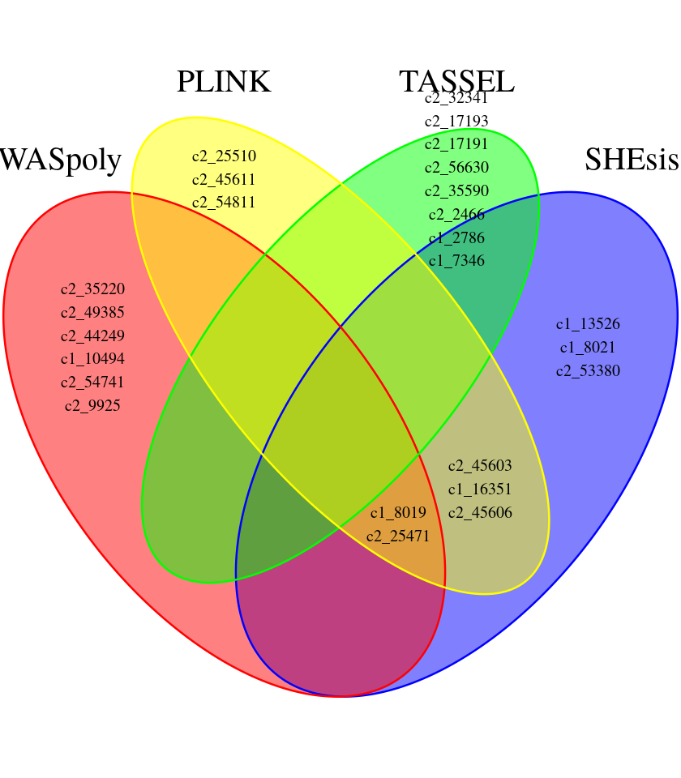

# 3 Significative SNPs

This section shows a table and a Venn diagram for the signifcative SNPs (score is above the significance threshold for each tool).

## 3.1 Table of significative SNPs

The following table shows the associations between SNPs and the trait as transformed p-values to scores as -log 10 (p-value) sorted from the highest to the lowest scores based on each tool analysis and the model selected (Full or Naive). Each SNP has its associated information, such as the chromosome, position in the genome, and name.

| TOOL | MODEL | GC | SNP | CHROM | POSITION | PVALUE | SCORE | THRESHOLD | SIGNIFICANCE |
| --- | --- | --- | --- | --- | --- | --- | --- | --- | --- |
| GWASpoly | general | 1.039 | c1_8019 | 10 | 48863165 | 0e+00 | 7.9900 | 4.8200 | TRUE |
| GWASpoly | general | 1.039 | c2_25471 | 10 | 48808404 | 5e-06 | 5.2700 | 4.8200 | TRUE |
| PLINK | additive | 4.162 | c1_8019 | 10 | 48863165 | 0e+00 | 16.0598 | 4.8402 | TRUE |
| PLINK | additive | 4.162 | c2_25510 | 10 | 48679881 | 0e+00 | 13.8935 | 4.8402 | TRUE |
| PLINK | additive | 4.162 | c2_25471 | 10 | 48808404 | 0e+00 | 13.4407 | 4.8402 | TRUE |
| PLINK | additive | 4.162 | c2_45606 | 10 | 48218826 | 0e+00 | 12.7625 | 4.8402 | TRUE |
| PLINK | additive | 4.162 | c2_45603 | 10 | 48073593 | 0e+00 | 12.3502 | 4.8402 | TRUE |
| PLINK | additive | 4.162 | c2_45611 | 10 | 48203431 | 0e+00 | 12.1996 | 4.8402 | TRUE |
| PLINK | additive | 4.162 | c2_54811 | 1 | 46270954 | 0e+00 | 11.6763 | 4.8402 | TRUE |
| PLINK | additive | 4.162 | c1_16351 | 10 | 48761642 | 0e+00 | 11.0568 | 4.8402 | TRUE |
| SHEsis | general | 5.878 | c1_8019 | 10 | 48863165 | 0e+00 | 22.0297 | 4.8477 | TRUE |
| SHEsis | general | 5.878 | c2_25471 | 10 | 48808404 | 0e+00 | 17.2581 | 4.8477 | TRUE |
| SHEsis | general | 5.878 | c2_45603 | 10 | 48073593 | 0e+00 | 15.9547 | 4.8477 | TRUE |
| SHEsis | general | 5.878 | c1_13526 | 10 | 48020996 | 0e+00 | 15.6576 | 4.8477 | TRUE |
| SHEsis | general | 5.878 | c1_16351 | 10 | 48761642 | 0e+00 | 15.2351 | 4.8477 | TRUE |
| SHEsis | general | 5.878 | c1_8021 | 10 | 48862950 | 0e+00 | 15.1433 | 4.8477 | TRUE |
| SHEsis | general | 5.878 | c2_45606 | 10 | 48218826 | 0e+00 | 15.0414 | 4.8477 | TRUE |
| SHEsis | general | 5.878 | c2_53380 | 1 | 70371898 | 0e+00 | 14.7122 | 4.8477 | TRUE |

## 3.2 Venn diagram of significative SNPs

The Venn diagram shows the significative SNPs that are either unique or shared by the four software. Shared SNPs appear in the intersection areas of the diagram.

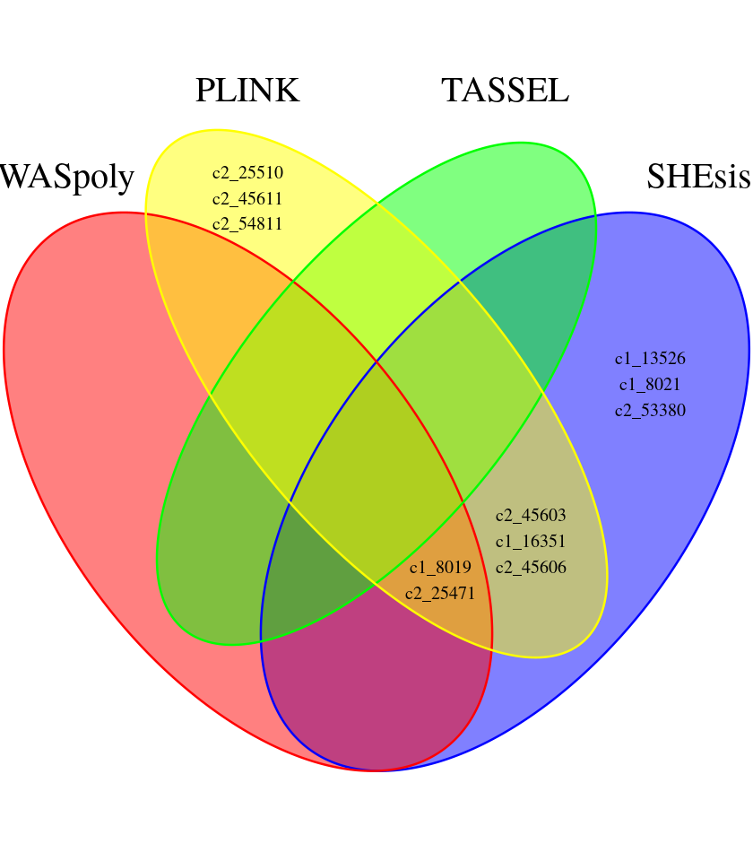

# 4 Manhattan and QQ plots

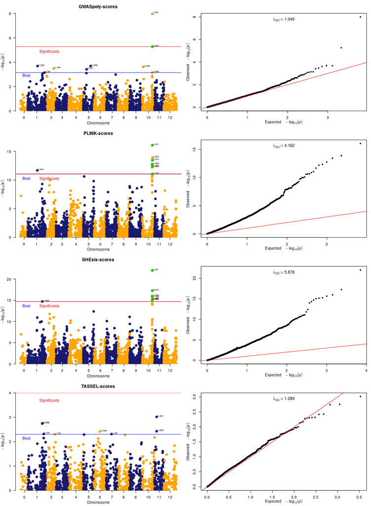

# 5 Profiles for common significative SNPs

Because each multiGWAS report shows one specific trait at a time, the histogram and color key will remain the same for all the best-ranked SNPs.

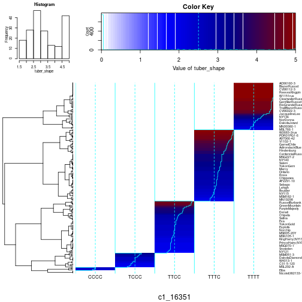

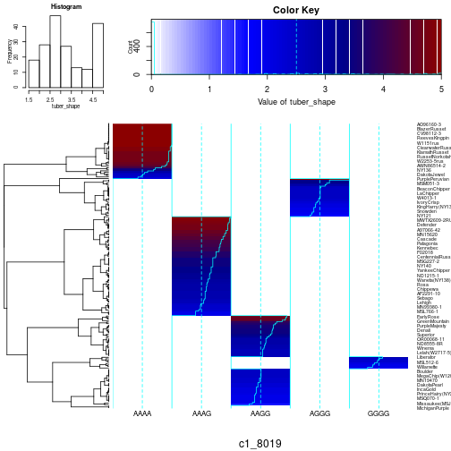

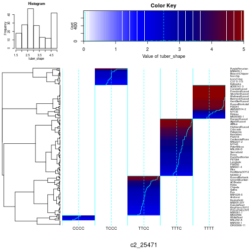

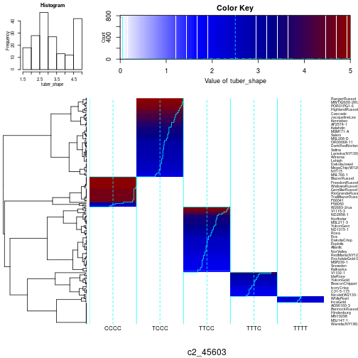

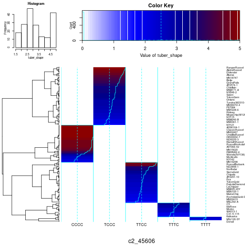